# P8105 HW1

Zakari L. Billo

09/20/2025

Load libraries

```r
library(tidyverse)
library(moderndive)
```

# Problem 1

```r
data("early_january_weather") #load dataset

weather_df <- early_january_weather |>
  janitor::clean_names() #clean names in new df, preserve original

summary(weather_df) #view summary
```

```
##     origin               year          month        day              hour
##  Length:358         Min.   :2013   Min.   :1   Min.   : 1.000   Min.   : 0.00
##  Class :character   1st Qu.:2013   1st Qu.:1   1st Qu.: 4.000   1st Qu.: 6.00
##  Mode  :character   Median :2013   Median :1   Median : 8.000   Median :11.50
##                     Mean   :2013   Mean   :1   Mean   : 8.039   Mean   :11.53
##                     3rd Qu.:2013   3rd Qu.:1   3rd Qu.:12.000   3rd Qu.:17.75
##                     Max.   :2013   Max.   :1   Max.   :15.000   Max.   :23.00
##
##       temp            dewp           humid           wind_dir
##  Min.   :24.08   Min.   : 8.96   Min.   : 32.86   Min.   :  0.0
##  1st Qu.:33.98   1st Qu.:19.94   1st Qu.: 51.34   1st Qu.:140.0
##  Median :39.02   Median :26.06   Median : 61.67   Median :240.0
##  Mean   :39.58   Mean   :28.06   Mean   : 65.48   Mean   :208.2
##  3rd Qu.:44.96   3rd Qu.:35.06   3rd Qu.: 78.68   3rd Qu.:290.0
##  Max.   :57.92   Max.   :53.06   Max.   :100.00   Max.   :360.0
##                                                   NA's   :5
##    wind_speed       wind_gust         precip            pressure
##  Min.   : 0.000   Min.   :16.11   Min.   :0.000000   Min.   :1011
##  1st Qu.: 5.754   1st Qu.:19.56   1st Qu.:0.000000   1st Qu.:1018
##  Median : 8.055   Median :21.86   Median :0.000000   Median :1022
##  Mean   : 8.226   Mean   :22.53   Mean   :0.002039   Mean   :1023
##  3rd Qu.:11.508   3rd Qu.:25.32   3rd Qu.:0.000000   3rd Qu.:1027
##  Max.   :24.166   Max.   :31.07   Max.   :0.190000   Max.   :1034
##                   NA's   :308                        NA's   :38
##      visib          time_hour
##  Min.   : 0.120   Min.   :2013-01-01 01:00:00
##  1st Qu.: 9.000   1st Qu.:2013-01-04 19:15:00
##  Median :10.000   Median :2013-01-08 12:30:00
##  Mean   : 8.515   Mean   :2013-01-08 12:28:09
##  3rd Qu.:10.000   3rd Qu.:2013-01-12 05:45:00
##  Max.   :10.000   Max.   :2013-01-15 23:00:00
##
```

```r
print(nrow(weather_df)) #358 rows
```

```
## [1] 358
```

```r
print(ncol(weather_df)) #15 col
```

```
## [1] 15
```

```r
print(mean(pull(weather_df, temp))) #39.58212
```

```
## [1] 39.58212
```

The dataset “early_january_weather” (renamed weather_df) contains 15 variables (reflecting 15 columns) and 358 observations (reflecting 358 rows): * `origin`: airport code (EWR) * `year`: 2013 * `month`: january * `day`: january 1-15th * `hour`: 12:00 am - 23:00 pm * `temp`: mean = 39.58212 (ªF) * `dewp`: mean = 28.06 (ªF) * `humid`: mean = 65.48 (%) * `wind_dir`: mean = 208.2 (degrees from north) * `wind_speed`: mean = 8.226 (mph) * `wind_gust`: mean = 22.53 (mph) * `precip`: mean = 0.002039 (inches) * `pressure`: mean = 1023 (millibars) * `visib`: mean = 8.515 (miles) * `time_hour`: range jan 1st at 01:00:00 am to jan 15th at 23:00:00 pm

As requested, the mean temperature was 39.58212 (ªF).

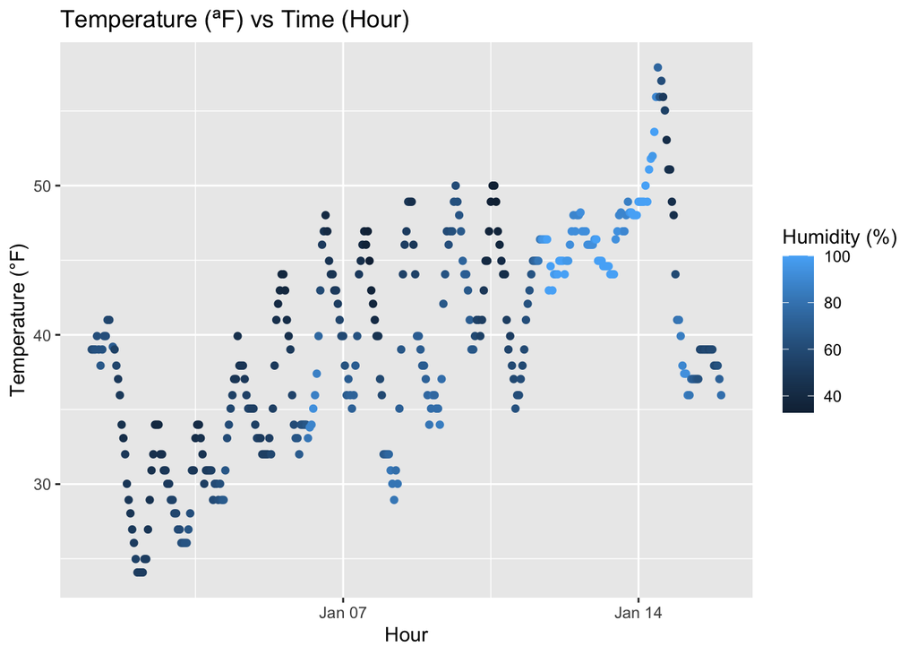

```r
# scatterplot of `temp` vs. `time` w `humid` as color
ggplot(weather_df, aes(x = time_hour, y = temp, color = humid)) +
  geom_point() +
  labs( #labels
    title = "Temperature (ªF) vs Time (Hour)",
    x = "Hour",
    y = "Temperature (°F)",
    color = "Humidity (%)"
  )
```

```r
#export plot
ggsave('temp_hour_scatter.jpeg')
```

## Problem 2

```r
#create a tibble
q2_df <- tibble(
  num_vec = rnorm(10), #random normal sample
  above_0 = num_vec > 0, #check if num_vec is above 0
  char_vec = letters[1:10], #character vector
  fact_vec = factor(rep(c("1", "2", "3"), length = 10)) #factor vector
  )

#take all means
print(mean(pull(q2_df, num_vec)))
```

```
## [1] -0.01633404
```

```r
print(mean(pull(q2_df, above_0)))
```

```
## [1] 0.7
```

```r
print(mean(pull(q2_df, char_vec)))
```

```
## [1] NA
```

```r
print(mean(pull(q2_df, fact_vec)))
```

```
## [1] NA
```

Taking the means of the numerical vector `num_vec` and the logical vector `above_0` worked, but I was unable to take the mean of the character vector `char_vec` and the factor vector `fact_vec`.

```r
#convert to numeric values
as.numeric(pull(q2_df, above_0))
as.numeric(pull(q2_df, char_vec))
as.numeric(pull(q2_df, fact_vec))
```

[output not shown]

The logical vector `above_0` was converted to a binary numeric, and the factor vector `fact_vec` took on the values of its factor levels, but I was unable to coerce the character vector `char_vec` into a numerical vector because they were all converted to NAs. This helps explain why the previous means() code failed.